# Section 11

Natalia Garbiras-Díaz

April 14, 2017

## Today

- Fixed effects
- RD designs
- Spillover Effects

## Panel data

Panel data (also known as longitudinal data) is a data set in which the behavior of entities are observed across time. These entities could be states, companies, individuals, countries, etc.

```r
head(country_data)
```

```
##   country year           y        x1
## 1       A 1990  1342787840 0.2779036
## 2       A 1991 -1899660544 0.3206847
## 3       A 1992   -11234363 0.3634657
## 4       A 1993  2645775360 0.2461440
## 5       A 1994  3008334848 0.4246230
## 6       A 1995  3229574144 0.4772141
```

For this exercise, we will focus on the heterogeneity across countries:

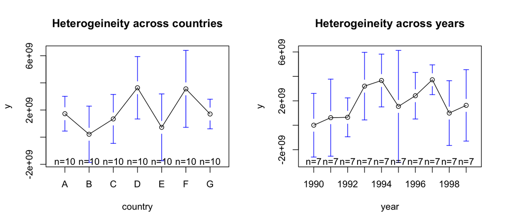

```r
par(mfrow=c(1,2))
plotmeans(y ~ country, main="Heterogeineity across countries", data=country_data)
plotmeans(y ~ year, main="Heterogeineity across years", data=country_data)
```

Regular OLS does not consider heterogeneity across groups or time…

```r
ols <-lm(y ~ x1, data=country_data)
summary(ols)
```

```
##
## Call:
## lm(formula = y ~ x1, data = country_data)
##
## Residuals:
##        Min         1Q     Median         3Q        Max
## -9.546e+09 -1.578e+09  1.554e+08  1.422e+09  7.183e+09
##
## Coefficients:
##              Estimate Std. Error t value Pr(>|t|)
## (Intercept) 1.524e+09  6.211e+08   2.454   0.0167 *
## x1          4.950e+08  7.789e+08   0.636   0.5272
## ---
## Signif. codes:  0 '***' 0.001 '**' 0.01 '*' 0.05 '.' 0.1 ' ' 1
##
## Residual standard error: 3.028e+09 on 68 degrees of freedom
## Multiple R-squared:  0.005905,   Adjusted R-squared:  -0.008714
## F-statistic: 0.4039 on 1 and 68 DF,  p-value: 0.5272
```

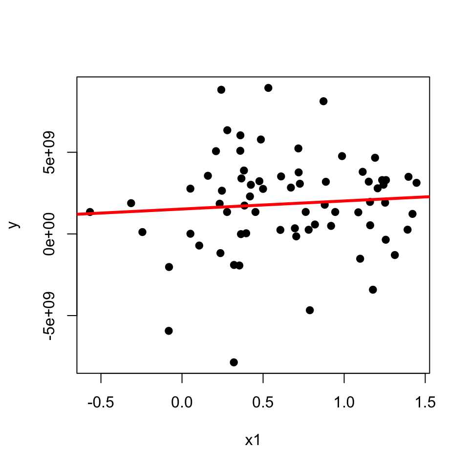

```r
par(mfrow=c(1,1))
plot(country_data$x1, country_data$y, pch=19, xlab="x1", ylab="y")
abline(lm(country_data$y~country_data$x1),lwd=3, col="red")
```

## Fixed effects

Fixed-effects models help to isolate the effects of within-unit variation—though coefficients are pooled across units.

$$Y_{it}= \alpha_i + \beta D_{it} + \epsilon_{it}$$
where there is one dummy variable (``fixed effect“) $\alpha_i$ for each unit $i$ (here unit=country). This fixed-effect is a unit-specific intercept.

How will the design matrix look here?

```r
fixed.dum <-lm(y ~ x1 + factor(country) - 1, data=country_data)
summary(fixed.dum)
```

```
##
## Call:
## lm(formula = y ~ x1 + factor(country) - 1, data = country_data)
##
## Residuals:
##        Min         1Q     Median         3Q        Max
## -8.634e+09 -9.697e+08  5.405e+08  1.386e+09  5.612e+09
##
## Coefficients:
##                    Estimate Std. Error t value Pr(>|t|)
## x1                2.476e+09  1.107e+09   2.237  0.02889 *
## factor(country)A  8.805e+08  9.618e+08   0.916  0.36347
## factor(country)B -1.058e+09  1.051e+09  -1.006  0.31811
## factor(country)C -1.723e+09  1.632e+09  -1.056  0.29508
## factor(country)D  3.163e+09  9.095e+08   3.478  0.00093 ***
## factor(country)E -6.026e+08  1.064e+09  -0.566  0.57329
## factor(country)F  2.011e+09  1.123e+09   1.791  0.07821 .
## factor(country)G -9.847e+08  1.493e+09  -0.660  0.51190
## ---
## Signif. codes:  0 '***' 0.001 '**' 0.01 '*' 0.05 '.' 0.1 ' ' 1
##
## Residual standard error: 2.796e+09 on 62 degrees of freedom
## Multiple R-squared:  0.4402, Adjusted R-squared:  0.368
## F-statistic: 6.095 on 8 and 62 DF,  p-value: 8.892e-06
```

Each component of the factor variable (country) is absorbing the variation particular to each country.

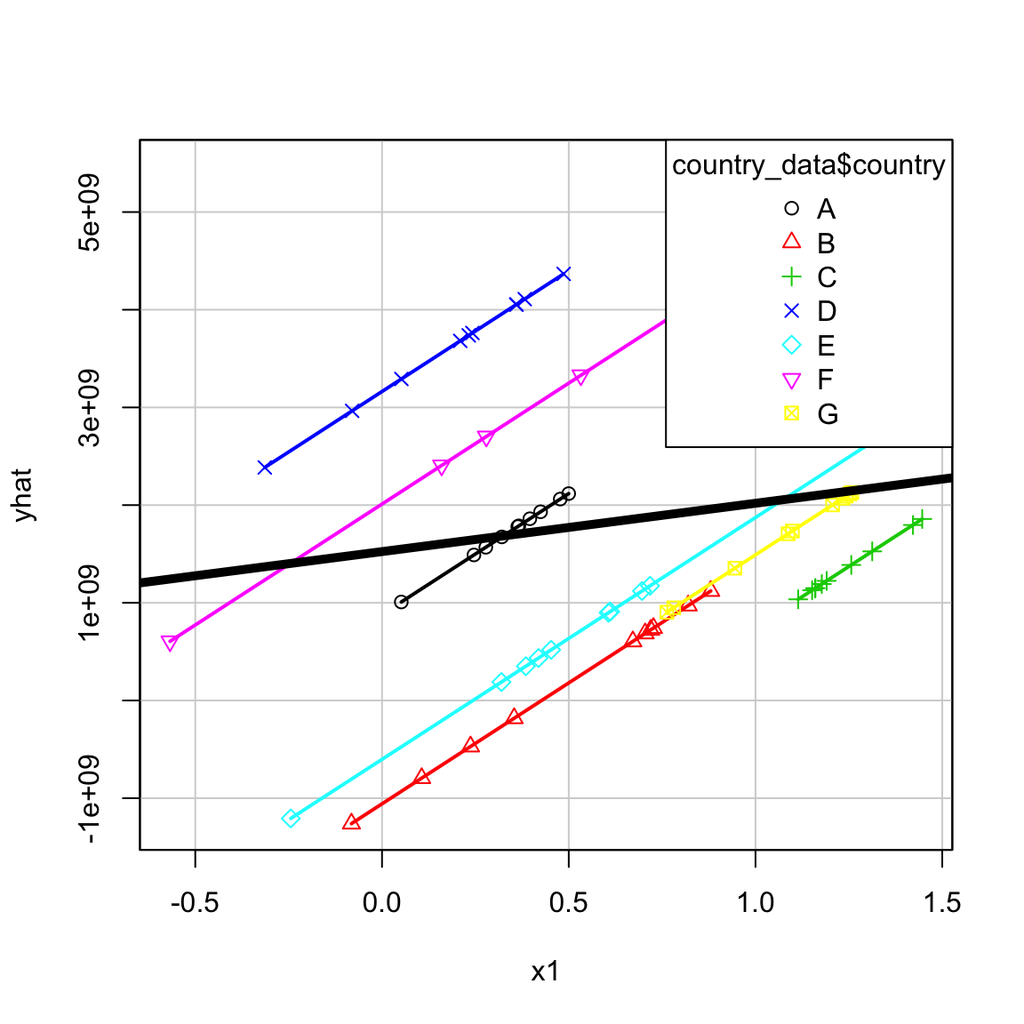

```r
yhat <- fixed.dum$fitted
scatterplot(yhat~country_data$x1|country_data$country,
            xlab="x1", ylab="yhat", legend.coords="topright")
abline(lm(country_data$y~country_data$x1), lwd=5, col="black")
```

## Regression Discontinuity Design

[figure not shown]

## Regression Discontinuity Design

[figure not shown]

## Exercise

[figure not shown]

We will use `rddata.Rda` to estimate the effect of having a left-wing party in office on social spending

```r
load("~/Dropbox/Academic/UC_Berkeley/GSI/PS_231B/Section_slides/Section_11/rddata.Rda")
head(data)
```

```
##   municipality  party  vs_2000  vs_2004 soc_spend
## 1            1 center 41.72421 36.56648  40.67018
## 2            1   left 43.23756 46.25497  48.98232
## 3            1  right 15.03822 17.17855  10.34750
## 4            2   left 33.82809 37.67917  37.96897
## 5            2  right 35.08161 37.52963  35.12098
## 6            2 center 31.09030 24.79119  26.91006
```

```r
# How many municipalities?
length(unique(data$municipality))
```

```
## [1] 6000
```

```r
# How many candidates per municipality?
nr_cand <- NA
for (i in 1:6000){ nr_cand[i] <- nrow(data[data$municipality==i,]) }
mean(nr_cand)
```

```
## [1] 3
```

```r
sd(nr_cand)
```

```
## [1] 0
```

```r
# NA observations for running variable?
sum(is.na(data$vs_2000))
```

```
## [1] 0
```

What type of dataset do we need for the RD analysis? How can we build it?

```r
# Building RD dataset
rd_data <- NA

for (i in 1:6000){

    # get mini muni data
    temp <- data[data$municipality==i, ]
    # 1. keep winner and loser
    temp$order <- order(temp$vs_2000, decreasing = TRUE)
    temp <- temp[temp$order!=3, ]

    # 2. drop if no left
    temp$left <- ifelse(temp$party=="left", 1, 0)
    if (sum(temp$left)==0) {temp$margin <- NA}

    # 3. left margin
    if (sum(temp$left)==1){
        temp$margin <- temp$vs_2000[temp$left==1] -
            temp$vs_2000[temp$left==0]}

    # put together in final dataset
    rd_data <- rbind(rd_data, temp)

    if (i/1000==round(i/1000)) print(i)

}
```

```
## [1] 1000
## [1] 2000
## [1] 3000
## [1] 4000
## [1] 5000
## [1] 6000
```

```r
head(rd_data)
```

```
##   municipality  party  vs_2000  vs_2004 soc_spend order left    margin
## 1           NA   <NA>       NA       NA        NA    NA   NA        NA
## 2            1 center 41.72421 36.56648  40.67018     2    0  1.513347
## 3            1   left 43.23756 46.25497  48.98232     1    1  1.513347
## 4            2   left 33.82809 37.67917  37.96897     2    1 -1.253524
## 5            2  right 35.08161 37.52963  35.12098     1    0 -1.253524
## 7            3 center 34.91674 33.81395  37.22732     2    0  3.415483
```

```r
# dropping cases with no left wing party winner or runner up
rd_data <- rd_data[is.na(rd_data$margin)==F, ]
head(rd_data)
```

```
##   municipality  party  vs_2000  vs_2004 soc_spend order left    margin
## 2            1 center 41.72421 36.56648  40.67018     2    0  1.513347
## 3            1   left 43.23756 46.25497  48.98232     1    1  1.513347
## 4            2   left 33.82809 37.67917  37.96897     2    1 -1.253524
## 5            2  right 35.08161 37.52963  35.12098     1    0 -1.253524
## 7            3 center 34.91674 33.81395  37.22732     2    0  3.415483
## 8            3   left 38.33222 48.28878  47.91241     1    1  3.415483
```

```r
dim(rd_data)
```

```
## [1] 8100    8
```

```r
length(unique(rd_data$municipality))
```

```
## [1] 4050
```

```r
# creating the treatment variable
rd_data$treat <- ifelse(rd_data$left==1 & rd_data$margin>=0, 1, 0)
table(rd_data$treat)
```

```
##
##    0    1
## 6042 2058
```

```r
# keeping only the winner
rd_data <- rd_data[rd_data$order==1, ]
table(rd_data$treat)
```

```
##
##    0    1
## 2064 1986
```

```r
# t-test in 5% margin
with(rd_data[abs(rd_data$margin)<=5, ],
     t.test(soc_spend ~ treat))
```

```
##
##  Welch Two Sample t-test
##
## data:  soc_spend by treat
## t = -28.315, df = 1611.6, p-value < 2.2e-16
## alternative hypothesis: true difference in means is not equal to 0
## 95 percent confidence interval:
##  -8.875902 -7.725876
## sample estimates:
## mean in group 0 mean in group 1
##        36.22034        44.52122
```

# Graphical representation of estimated effect across bandwidths (Bueno and Tuñón 2015)

```r
#Difference of means (using OLS with robust standard errors)
dom <- function(rescaled, treat, outcome){ model <- lm(outcome~treat)
est <- NA
est[1] <- model$coefficients[2]
est[2] <- sqrt(diag(vcovHC(model,type="HC3"))[2])
return(est) }
```

```r
# Plotting function
RD_plot <- function(

  # Data
  running=running,
  treat=treat,
  outcome=outcome,
  cutoff=0,
  min_running=F,
  max_running=F,

  # Intervals and Opt bw
  opt_bw=F, # opt bw
  nr_windows=50,

  # Estimator/s
  # Main Estimator
  main_est="dom",
  # estimator
  #confidence intervals
  ci="95%", #options: ci="90%", ci="F"

  #Plot aesthetics
  nr_obs=T,
  nr_obs_lab,
  label_x="Absolute distance from the cutoff",
  label_y="Estimated effect",
  plot_label="RD plot",
  label_size=1.2,
  main_size=2,
  legend=F # Keep false if desired output is grid of plots
  ){

  # WARNINGS
  if (cutoff==0) print("Assuming that cutoff is at the value of 0 for the running variable. \n
                       To change this, input new value for the cutoff argument.")
  if (cutoff!=0) print("Rescaling the running variable to place cutoff at zero.")

  library("sandwich")
  print("This function requires the sandwich package")

  # DATA
  # 0. rescaling running var and organizing data
  rescaled <- running - cutoff
  abs_running <- abs(rescaled)
  data <- cbind(rescaled, treat, outcome, abs_running, running)

  # 1. get windows from intervals and add optimal bandwidth
  min_running <- ifelse(min_running==F, 0, min_running-cutoff)
  max_running <- ifelse(max_running==F, max(abs_running), max_running-cutoff)
  windows <- seq(min_running, max_running,by=(max_running/nr_windows))[-1]
  if (opt_bw!=F) windows <- sort(c(windows, opt_bw))
  if (opt_bw!=F) print("Assuming optimal bandwidth measured as distance from the cutoff.")

  # 2. calculate estimate(s) and CI
  main <- dom
  ests <- matrix(NA,length(windows),3)
  for (i in 1:length(windows)){
    # select data
    temp <- as.data.frame(data[abs_running<=windows[i],])
    ests[i,1:2] <- with(temp, main(rescaled=rescaled, treat=treat, outcome=outcome))}

  # Confidence intervals for main estimate
  if (ci=="95%") CI <- cbind(ests[,1]+1.96*ests[,2],ests[,1]-1.96*ests[,2])
  if (ci=="90%") CI <- cbind(ests[,1]+1.64*ests[,2],ests[,1]-1.64*ests[,2])

  # Define max and min for y axis
  lim_y <- c(max(CI), min(CI))
  lim_y[3] <- lim_y[2] - (lim_y[1]-lim_y[2])/7
  lim_y[4] <- lim_y[1] - (lim_y[1]-lim_y[2])/11

  # Define max for x axis
  if (abs(opt_bw) > abs(max_running)) max_axis <- opt_bw
  if (abs(opt_bw) < abs(max_running)) max_axis <- max_running

  # 3. ordering to know number of observations by value of running variable
  data <- as.data.frame(data[order(abs_running),])
  if (nr_obs==T) {
    if (missing(nr_obs_lab))
      stop("Missing specification for number of observations to be included in the plot. \n
           If no axis for the number of observations is needed, use nr_obs=F.")
    nr_obs_lab <- cbind(nr_obs_lab, data$abs_running[nr_obs_lab])}

  # PLOT
  # Main line (add types, mins and maxs)
  if(legend==F){
    par(mar=c(4.1,6.1,6.1,2.1))
    plot(windows, ests[,1], pch=16, axes=T,
         #limits
         ylim=c(lim_y[3],lim_y[1]),
         xlim=c(0, max_axis),
         #labels
         xlab=label_x, ylab=label_y, main=plot_label,
         bty='n', cex.main=main_size,
         cex.lab=label_size,
         cex=1.2)
    #Zero effect line
    abline(h=0, lty=4, lw=3)
    #opt bw vertical line
    if(opt_bw!=F){
      abline(v=opt_bw, lty=5, col="gray80", lw=3)}

    # Add estimates line
    lines(windows, ests[,3], lwd=3,col="gray30")
    # CIs
    if(ci!=F){
      lines(windows, CI[,1], lty=2,col="gray30")
      lines(windows, CI[,2], lty=2,col="gray30")}
    # Number of observations
    if (nr_obs==T) {
      axis(3, at=c(nr_obs_lab[,2]), labels=c(nr_obs_lab[,1]), cex=.6, col="grey50",
           lwd = 0.5, padj=1, line=1, cex.axis=.7, col.axis="grey50")
      mtext("Number of observations", side=3, col="grey50", cex=.7, adj=0)}
  }

  if(legend==T){
  layout(rbind(1,2), heights=c(7,1))
  par(mar=c(4.1,6.1,6.1,2.1))
  plot(windows, ests[,1], pch=16, axes=T,
       #limits
       ylim=c(lim_y[3],lim_y[1]),
       xlim=c(0, max_axis),
       #labels
       xlab=label_x, ylab=label_y, bty='n',
       cex.lab=label_size,
       cex=1.2)
  # title
  title(plot_label, cex.main=main_size, line=4)
  #Zero effect line
  abline(h=0, lty=4, lw=3)
  #opt bw vertical line
  if(opt_bw!=F){
  abline(v=opt_bw, lty=5, col="gray80", lw=3)}

  # Add estimates line
  lines(windows, ests[,3], lwd=3,col="gray30")
  # CIs
  if(ci!=F){
    lines(windows, CI[,1], lty=2,col="gray30")
    lines(windows, CI[,2], lty=2,col="gray30")}
  # Number of observations
  if (nr_obs==T) {
    axis(3, at=c(nr_obs_lab[,2]), labels=c(nr_obs_lab[,1]), cex=.6, col="grey50",
         lwd = 0.5, padj=1, line=1, cex.axis=.7, col.axis="grey50")
    mtext("Number of observations", side=3, col="grey50", cex=.7, adj=0)}

  # Legend
  par(mar=c(0.5,0,0,0))
  plot.new()
  main_leg <- "Difference of Means"
  if (ci=="95%") ci_leg <- paste("95% Confidence Intervals ", "(", main_leg, ")", sep="")
  if (ci=="90%") ci_leg <- paste("90% Confidence Intervals ", "(", main_leg, ")", sep="")

  legend("center", "groups", c(main_leg, ci_leg), pch=c(16, NA), lty=c(NA, 2), lwd=c(2, 2),
           col=c("black", "gray"), bty="n", cex=0.8)
  }

}
```

# Plot our estimator across different bandwidths

```
## [1] "Assuming that cutoff is at the value of 0 for the running variable. \n \n                       To change this, input new value for the cutoff argument."
## [1] "This function requires the sandwich package"
```

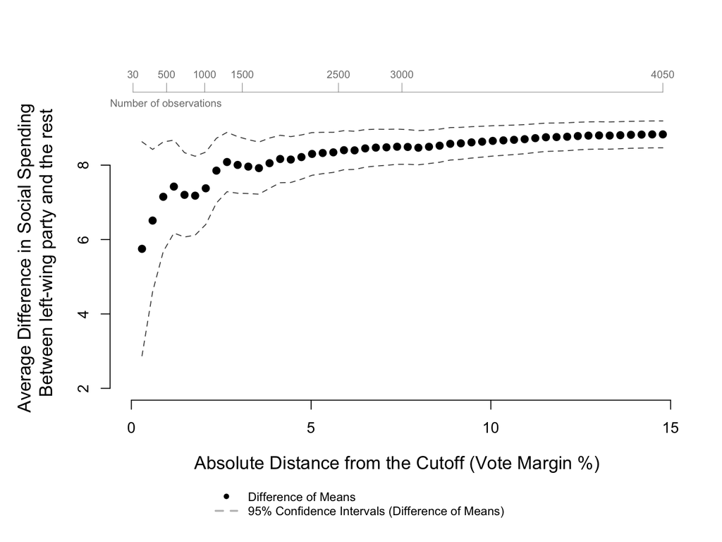

```r
RD_plot(running=rd_data$margin, treat=rd_data$treat,
        outcome=rd_data$soc_spend,
        cutoff=0, nr_windows=50, main_est="dom", ci="95%",
        nr_obs=T,
        nr_obs_lab=c(30, 500, 1000, 1500, 2500, 3000, 4050),
        label_x="Absolute Distance from the Cutoff (Vote Margin %)",
        label_y="Average Difference in Social Spending \n Between left-wing party and the rest",
        plot_label=" ",
        legend=T)
```

Reduction in CIs (recall the trade-off between bias and precision)

## Nickerson (2008): Is Voting Contagious?

In-house voter behavior is correlated, but how much of this is “contagion”

Strategy: Treat only one voter in two-voter households, but measure the outcome for both voters.

Can we estimate the spillover effects by comparing treated and control households?

- If you only compare treated and control, you don’t know who would have answered the door for the control group.
- Why could this be a problem?

## Nickerson (2008): Is Voting Contagious?

Idea: placebo treatment.

A placebo treatment allows to record who answers the door for both treatment and placebo group.

By identifying “primary” contacted and “secondary” units in each household, the spillover effect can be estimated.

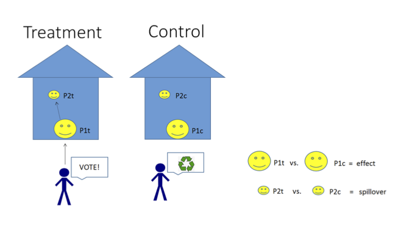

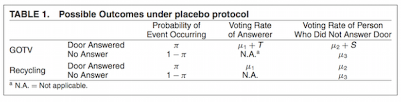

## Nickerson (2008): Is Voting Contagious?

# The data

```r
head(data)
```

```
##   family   city denver turf pct treatment reached other goaway moved can_t
## 1      1 DENVER      1   14  42         1       0     0      0     0     0
## 2      1 DENVER      1   14  42         1       0     0      0     0     0
## 3      2 DENVER      1   28  22         1       1     0      0     0     0
## 4      2 DENVER      1   28  22         1       0     1      0     0     0
## 5      3 DENVER      1   28  22         3       0     0      0     0     0
## 6      3 DENVER      1   28  22         3       0     0      0     0     0
##   hsecontact voted02p voted01 voted00 voted00p voted99 voted98      party
## 1          0        0       1       0        0       0       0 REPUBLICAN
## 2          0        0       1       1        0       0       1 REPUBLICAN
## 3          1        1       1       1        1       1       1 DEMOCRATIC
## 4          1        1       1       1        0       1       1 DEMOCRATIC
## 5          0        1       1       1        0       0       1 DEMOCRATIC
## 6          0        1       1       1        0       0       1 DEMOCRATIC
##   age gender
## 1  62      F
## 2  64      M
## 3  68      F
## 4  83      M
## 5  68      F
## 6  71      M
```

```r
table(data$reached, data$other)
```

```
##
##        0    1
##   0 5812  954
##   1  954    2
```

```r
table(data$treatment)
```

```
##
##    1    2    3
## 2572 2578 2572
```

## Replication

```r
contacted <- data[data$hsecontact==1, ]

table(contacted$treatment)
```

```
##
##   1   2
## 970 940
```

```r
contacted$treatment <- as.numeric(contacted$treatment==1)

table(contacted$treatment)
```

```
##
##   0   1
## 940 970
```

```r
direct <- with(contacted[contacted$reached==1, ],
               t.test(voted02p ~ treatment, alternative="less"))
direct
```

```
##
##  Welch Two Sample t-test
##
## data:  voted02p by treatment
## t = -3.0408, df = 953.07, p-value = 0.001212
## alternative hypothesis: true difference in means is less than 0
## 95 percent confidence interval:
##         -Inf -0.04267869
## sample estimates:
## mean in group 0 mean in group 1
##       0.2978723       0.3909465
```

```r
secondary <- with(contacted[contacted$other==1, ],
               t.test(voted02p ~ treatment, alternative="less"))
secondary
```

```
##
##  Welch Two Sample t-test
##
## data:  voted02p by treatment
## t = -1.8722, df = 953.81, p-value = 0.03074
## alternative hypothesis: true difference in means is less than 0
## 95 percent confidence interval:
##          -Inf -0.006791979
## sample estimates:
## mean in group 0 mean in group 1
##       0.2893617       0.3456790
```

## Looking at balance in the Nickerson experiment

```r
names(contacted)
```

```
##  [1] "family"     "city"       "denver"     "turf"       "pct"
##  [6] "treatment"  "reached"    "other"      "goaway"     "moved"
## [11] "can_t"      "hsecontact" "voted02p"   "voted01"    "voted00"
## [16] "voted00p"   "voted99"    "voted98"    "party"      "age"
## [21] "gender"
```

```r
with(contacted, t.test(age ~ treatment))$p.value
```

```
## [1] 0.5341056
```

```r
with(contacted, t.test(gender ~ treatment))$p.value
```

```
## [1] 0.7191029
```

```r
with(contacted, t.test(party ~ treatment))$p.value
```

```
## [1] 0.840486
```

```r
with(contacted, t.test(voted01 ~ treatment))$p.value
```

```
## [1] 0.296065
```

```r
with(contacted, t.test(voted00 ~ treatment))$p.value
```

```
## [1] 0.4156232
```

```r
with(contacted, t.test(voted00p ~ treatment))$p.value
```

```
## [1] 0.9677412
```

```r
with(contacted, t.test(voted99 ~ treatment))$p.value
```

```
## [1] 0.5504739
```

```r
with(contacted, t.test(voted98 ~ treatment))$p.value
```

```
## [1] 0.8231033
```

But how would we test whether the *set* of covariates can jointly predict treatment assignment better than chance?

## The F-test

The F-test is used to conduct a significant test for the joint hypothesis that all coefficients are zero. The null hypothesis is of the form $H_0 : \beta_1 = \beta_2 = . . . = \beta_k = 0$.

We are comparing two models: one in which the coefficients of the pre-treatment covariates are allowed to vary and another in which they are constrained to zero.

The test statistic is:

$F_{0}=\frac{(SSR_{r}-SSR_{ur})/q}{SSR_{ur}/(n-(k+1))}$

where $SSR_{r}$ stands for the sum of the squared residuals of the restricted model and $SSR_{ur}$ sum of the squared residuals of the unrestricted model. $n$ is the number of observations, $k$ is the number of independent variables in the unrestricted model and $q$ is the number of restrictions (or the number of coefficients being jointly tested).

The regression output in `R` reports the F-test:

```r
reg <- with(contacted,
            lm(treatment ~ age + gender + party + voted01 + voted00 + voted00p + voted99 + voted98))
```

```r
summary(reg)
```

```
##
## Call:
## lm(formula = treatment ~ age + gender + party + voted01 + voted00 +
##     voted00p + voted99 + voted98)
##
## Residuals:
##     Min      1Q  Median      3Q     Max
## -0.5910 -0.5074  0.4491  0.4901  0.5611
##
## Coefficients:
##               Estimate Std. Error t value Pr(>|t|)
## (Intercept)  0.5627552  0.0469580  11.984   <2e-16 ***
## age         -0.0007298  0.0007489  -0.975    0.330
## gender      -0.0084457  0.0270020  -0.313    0.754
## party       -0.0046523  0.0263297  -0.177    0.860
## voted01      0.0353783  0.0276287   1.280    0.201
## voted00     -0.0481394  0.0393599  -1.223    0.221
## voted00p    -0.0093012  0.0291275  -0.319    0.750
## voted99      0.0184154  0.0283645   0.649    0.516
## voted98      0.0079868  0.0306426   0.261    0.794
## ---
## Signif. codes:  0 '***' 0.001 '**' 0.01 '*' 0.05 '.' 0.1 ' ' 1
##
## Residual standard error: 0.5006 on 1901 degrees of freedom
## Multiple R-squared:  0.002143,   Adjusted R-squared:  -0.002056
## F-statistic: 0.5103 on 8 and 1901 DF,  p-value: 0.8494
```

```r
names(summary(reg))
```

```
##  [1] "call"          "terms"         "residuals"     "coefficients"
##  [5] "aliased"       "sigma"         "df"            "r.squared"
##  [9] "adj.r.squared" "fstatistic"    "cov.unscaled"
```

```r
summary(reg)$fstatistic
```

```
##        value        numdf        dendf
##    0.5102919    8.0000000 1901.0000000
```

We can also calculate the F-test by hand. We first need $SSR_{ur}$.

```r
SSRur <- sum(reg$residuals^2)
SSRur
```

```
## [1] 476.3592
```

What about $SSR_{r}$. What is this restricted model?

```r
regr <- with(contacted, lm(treatment ~ 1))

SSRr <- sum(regr$residuals^2)
SSRr
```

```
## [1] 477.3822
```

What are $n$, $q$ and $k$?

$n$ is the number of observations,

```r
n <- nrow(contacted)
```

$k$ is the number of independent variables in the unrestricted model

```r
reg$coefficients
```

```
##  (Intercept)          age       gender        party      voted01
##  0.562755172 -0.000729799 -0.008445681 -0.004652306  0.035378272
##      voted00     voted00p      voted99      voted98
## -0.048139449 -0.009301187  0.018415401  0.007986835
```

```r
length(reg$coefficients)
```

```
## [1] 9
```

```r
k <- length(reg$coefficients) - 1
```

and $q$ is the number of restrictions.

```r
q <- length(reg$coefficients) - 1
```

Recall $F_{0}=\frac{(SSR_{r}-SSR_{ur})/q}{SSR_{ur}/(n-(k+1))}$

```r
df1 <- q
df2 <- n-(k+1)

F0 <- ((SSRr-SSRur)/df1) / (SSRur/df2)
F0
```

```
## [1] 0.5102919
```

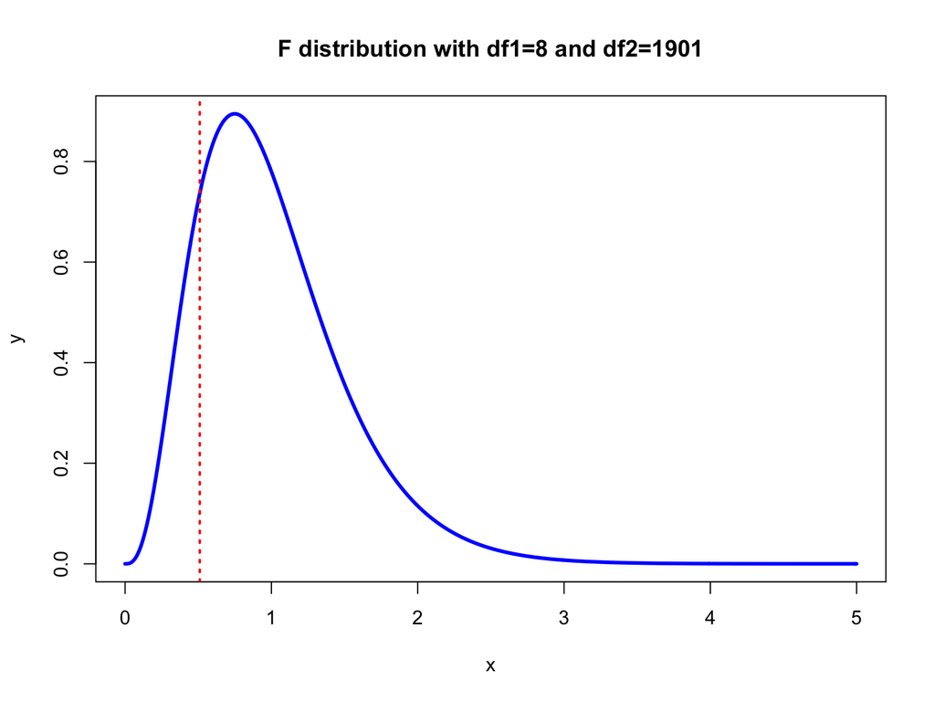

How do we calculate the p-value?

```r
F0
```

```
## [1] 0.5102919
```

```r
df1
```

```
## [1] 8
```

```r
df2
```

```
## [1] 1901
```

```r
1 - pf(F0, df1=df1, df2=df2)
```

```
## [1] 0.8494304
```

Does the validity of the test follow from the mechanical properties of OLS? What assumptions are we making?

We are assuming:

- treatment assignment is a linear combination of the covariates.
- normality of the error term in both regressions (where are we assuming this?)

Can we relax any of these assumptions?

## An alternative: randomization F-test

```r
library(ri)

perms <- genperms(Z=contacted$treatment)
```

```
## Too many permutations to use exact method.
## Defaulting to approximate method.
## Increase maxiter to at least Inf to perform exact estimation.
```

```r
dim(perms)
```

```
## [1]  1910 10000
```

```r
perm_f <- NULL

for (i in 1:ncol(perms)){

    contacted$treat <- perms[,i]

    reg <- with(contacted,
            lm(treat ~ age + gender + party + voted01 +
                   voted00 + voted00p + voted99 + voted98))

    perm_f[i] <- summary(reg)$fstatistic[1]

}

head(perm_f)
```

```
## [1] 0.6523589 0.8721353 1.2647547 0.4492475 0.8524776 1.0946212
```

```r
perm_fdist <- density(perm_f)
```

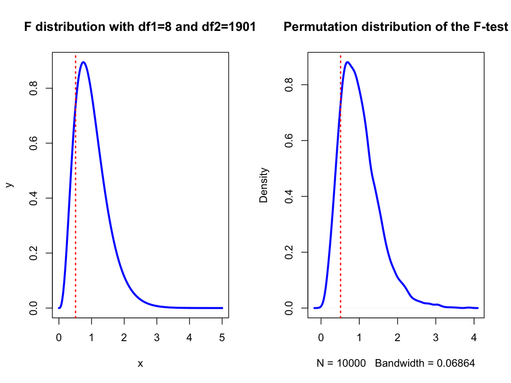